# BAAD: Biomass And Allometry Database — Detailed Summary

plant_scaling_data project

2026-05-01

# 1 Overview

The **Biomass And Allometry Database (BAAD)** is a curated, open-access compilation of individual-level plant structural measurements drawn from the primary literature. It was assembled and published by Falster et al. (2015) and is freely accessible via the `baad.data` R package (GitHub: traitecoevo/baad.data).

> **Reference:** Falster DS, Duursma RA, Ishihara MI, et al. (2015). BAAD: a Biomass And Allometry Database for woody plants. *Ecology*, 96(5):1445. DOI: 10.1890/14-1889.1

```r
n_rows    <- nrow(dat)
n_sp      <- length(unique(dat$speciesMatched))
n_studies <- length(unique(dat$studyName))
n_geo     <- sum(!is.na(dat$latitude))

kable(data.frame(
  Metric  = c("Total individual records", "Species (matched)", "Source studies",
               "Records with coordinates"),
  Value   = format(c(n_rows, n_sp, n_studies, n_geo), big.mark = ",")
), caption = "Top-level database summary")
```

Top-level database summary

| Metric | Value |
| --- | --- |
| Total individual records | 21,084 |
| Species (matched) | 656 |
| Source studies | 176 |
| Records with coordinates | 21,021 |

# 2 Data structure

## 2.1 Column dictionary

All trait columns have consistent units. The table below reproduces the BAAD data dictionary — the canonical reference for variable meanings and units.

```r
kable(dict, caption = "BAAD data dictionary (all variables)")
```

BAAD data dictionary (all variables)

| variable | units | group | type | has_methods | essential | label | minValue | maxValue | allowableValues | description |
| --- | --- | --- | --- | --- | --- | --- | --- | --- | --- | --- |
| location | NA | site | character | FALSE | TRUE | location | NA | NA | NA | name of location where sampled |
| latitude | deg | site | numeric | FALSE | TRUE | latitude | -90 | 9.0e+01 | NA | latitude of location where sampled (-90 to 90 deg South to North) |
| longitude | deg | site | numeric | FALSE | TRUE | longitude | -180 | 1.8e+02 | NA | longitude of location where sampled (-180 to 180 West to East) |
| vegetation | NA | site | character | FALSE | TRUE | vegetation | NA | NA | Sav,TropRF,TempRF,TropSF,TempF,BorF,Wo,Gr,Sh,De | vegetation type where sampled if grown in field (leave blank for plantations / glasshouse / common garden): Sav = Savannah; TropRF = Tropical rainforest; TempRF = Temperate rainforest; TropSF = Tropic… |
| map | mm | site | numeric | FALSE | FALSE | map | 100 | 1.2e+04 | NA | mean annual rainfall (wild grown plants only) |
| mat | deg | site | numeric | FALSE | FALSE | mat | -20 | 4.0e+01 | NA | mean annual temperature (wild grown plants only) |
| grouping | NA | stand | character | FALSE | FALSE | grouping | NA | NA | NA | any information about growing environment of sampled plant such as treatment or subplot |
| lai | m2/m2 | stand | numeric | TRUE | FALSE | lai | 0 | 3.0e+01 | NA | leaf area index of vegetation (wild plants only) |
| species | NA | species | character | FALSE | TRUE | species | NA | NA | NA | latin name of species (genus species) |
| speciesMatched | NA | species | character | FALSE | TRUE | speciesMatched | NA | NA | NA | latin name of species (genus species) checked against taxize database |
| family | NA | species | character | FALSE | FALSE | family | NA | NA | NA | family |
| pft | NA | species | character | FALSE | TRUE | pft | NA | NA | EA,DA,EG,DG | plant functional type: EA = evergreen angiosperm; DA = deciduous angiosperm; EG = evergreen gymnosperm; DG = deciduous gymnosperm |
| growingCondition | NA | tree | character | FALSE | TRUE | growing environment | NA | NA | FW,FE,GH,PU,PM,GC,CG | growing environment of sampled plant: FW = field wild; FE =field experimental; GH = glasshouse; PU = plantation unmanaged; PM = plantation managed; GC = growth chamber; CG = common garden |
| status | NA | tree | character | FALSE | TRUE | crown status | NA | NA | 0,1,2,3 | position in forest canopy (wild grown plants only): 0 = supressed; 1 = intermediate; 2 = codominant (crown partly exposed); 3 = dominant (crown fully exposed) |
| light | NA | tree | character | TRUE | FALSE | light environment | NA | NA | NA | note any information about light environment of sampled plant; we will determine appropriate categories once we see what information is available |
| age | yr | tree | numeric | TRUE | FALSE | age | 0 | 1.0e+03 | NA | age of plant expressed as decimal -> e.g. 3months = 0.25years |
| a.lf | m2 | tree | numeric | TRUE | FALSE | leaf area | 0 | 1.0e+04 | NA | leaf area of whole plant |
| a.ssba | m2 | tree | numeric | TRUE | FALSE | sapwood area at base | 0 | 1.0e+02 | NA | area of sapwood cross section at base |
| a.ssbh | m2 | tree | numeric | TRUE | FALSE | sapwood area at breast height | 0 | 1.0e+02 | NA | area of sapwood cross section at breast height |
| a.ssbc | m2 | tree | numeric | TRUE | FALSE | sapwood area at crown base | 0 | 1.0e+02 | NA | area of sapwood cross section at base of crown |
| a.shba | m2 | tree | numeric | TRUE | FALSE | heartwood area at base | 0 | 1.0e+02 | NA | area of heartwood cross section at base |
| a.shbh | m2 | tree | numeric | TRUE | FALSE | heartwood area at breast height | 0 | 1.0e+02 | NA | area of heartwood cross section at breast height |
| a.shbc | m2 | tree | numeric | TRUE | FALSE | heartwood area at crown base | 0 | 1.0e+02 | NA | area of heartwood cross section at base of crown |
| a.sbba | m2 | tree | numeric | TRUE | FALSE | bark area at base | 0 | 1.0e+02 | NA | area of bark cross section at base |
| a.sbbh | m2 | tree | numeric | TRUE | FALSE | bark area at breast height | 0 | 1.0e+02 | NA | area of bark cross section at breast height |
| a.sbbc | m2 | tree | numeric | TRUE | FALSE | bark area at crown base | 0 | 1.0e+02 | NA | area of bark cross section at base of crown |
| a.stba | m2 | tree | numeric | TRUE | FALSE | stem area at base | 0 | 1.0e+02 | NA | area of total stem cross-section at base of the plant |
| a.stbh | m2 | tree | numeric | TRUE | FALSE | stem area at breast height | 0 | 1.0e+02 | NA | area of total stem cross-section at breast height |
| a.stbc | m2 | tree | numeric | TRUE | FALSE | stem area at crown base | 0 | 1.0e+02 | NA | area of total stem cross-section at base of the crown |
| a.cp | m2 | tree | numeric | TRUE | FALSE | crown area | 0 | 1.0e+04 | NA | projected crown area as seen from above |
| a.cs | m2 | tree | numeric | TRUE | FALSE | crown surface area | 0 | 1.0e+04 | NA | surface area of whole crown |
| h.t | m | tree | numeric | TRUE | FALSE | height | 0 | 1.5e+02 | NA | total height of plant from ground to highest leaf |
| h.c | m | tree | numeric | TRUE | FALSE | height to crown base | 0 | 1.0e+02 | NA | height to crown base |
| d.ba | m | tree | numeric | TRUE | FALSE | basal diameter | 0 | 2.5e+01 | NA | diameter of stem at base |
| d.bh | m | tree | numeric | TRUE | FALSE | dbh | 0 | 2.5e+01 | NA | diameter of stem at breast height |
| h.bh | m | tree | numeric | FALSE | FALSE | height of d.bh measurement | 0 | 5.0e+01 | NA | height at which diameter at breast height (d.bh) is measured |
| d.cr | m | tree | numeric | TRUE | FALSE | crown width | 0 | 1.0e+02 | NA | diameter or width of crown |
| c.d | m | tree | numeric | TRUE | FALSE | crown depth | 0 | 1.0e+02 | NA | crown depth |
| m.lf | kg | tree | numeric | TRUE | FALSE | leaf mass | 0 | 1.0e+04 | NA | leaf mass |
| m.ss | kg | tree | numeric | TRUE | FALSE | sapwood mass | 0 | 1.0e+07 | NA | sapwood mass including branches |
| m.sh | kg | tree | numeric | TRUE | FALSE | heartwood mass | 0 | 1.0e+07 | NA | heartwood mass including branches |
| m.sb | kg | tree | numeric | TRUE | FALSE | bark mass | 0 | 1.0e+07 | NA | bark mass including branches |
| m.st | kg | tree | numeric | TRUE | FALSE | total stem mass | 0 | 1.0e+07 | NA | mass of all stem tissue including branches (=m.ss + m.sh + m.sb) |
| m.so | kg | tree | numeric | TRUE | FALSE | aboveground mass | 0 | 1.0e+07 | NA | mass of all above-ground structures (=m.lf + m.st) |
| m.br | kg | tree | numeric | TRUE | FALSE | branch mass | 0 | 1.0e+07 | NA | branch mass |
| m.rf | kg | tree | numeric | TRUE | FALSE | fine root mass | 0 | 1.0e+07 | NA | fine root mass |
| m.rc | kg | tree | numeric | TRUE | FALSE | coarse root mass | 0 | 1.0e+07 | NA | coarse root mass |
| m.rt | kg | tree | numeric | TRUE | FALSE | total root mass | 0 | 1.0e+07 | NA | total root mass (=m.rf+m.rc) |
| m.to | kg | tree | numeric | TRUE | FALSE | total mass | 0 | 1.0e+07 | NA | total mass (=m.rt+m.so) |
| a.ilf | m2 | tree | numeric | TRUE | FALSE | area of individual leaf | 0 | 1.0e+05 | NA | leaf size (average area of individual leaves across entire plant) |
| ma.ilf | kg/m2 | tree | numeric | TRUE | FALSE | leaf mass per area | 0 | 1.0e+01 | NA | leaf mass per area (average across entire plant or sample taken from top of plant; = m.lf/a.lf) |
| r.st | kg/m3 | tree | numeric | TRUE | FALSE | wood density | 0 | 2.0e+03 | NA | average density of all stem tissue (wood density) |
| r.ss | kg/m3 | tree | numeric | TRUE | FALSE | sapwood density | 0 | 2.0e+03 | NA | density of stem sapwood |
| r.sb | kg/m3 | tree | numeric | TRUE | FALSE | bark density | 0 | 2.0e+03 | NA | density of stem bark |
| r.sh | kg/m3 | tree | numeric | TRUE | FALSE | heartwood density | 0 | 2.0e+03 | NA | density of stem heartwood |
| n.lf | kg/kg | tree | numeric | TRUE | FALSE | leaf [nitrogen] | 0 | 1.0e-01 | NA | leaf nitrogen (average across entire plant or sample taken from top of plant) |
| n.ss | kg/kg | tree | numeric | TRUE | FALSE | sapwood [nitrogen] | 0 | 1.0e-01 | NA | nitrogen content of sapwood |
| n.sb | kg/kg | tree | numeric | TRUE | FALSE | bark [nitrogen] | 0 | 1.0e-01 | NA | nitrogen content of bark |
| n.sh | kg/kg | tree | numeric | TRUE | FALSE | heartwood [nitrogen] | 0 | 1.0e-01 | NA | nitrogen content of heartwood |
| n.rf | kg/kg | tree | numeric | TRUE | FALSE | fine root [nitrogen] | 0 | 1.0e-01 | NA | nitrogen content of fine roots |
| n.rc | kg/kg | tree | numeric | TRUE | FALSE | coarse root [nitrogen] | 0 | 1.0e-01 | NA | nitrogen content of coarse roots |

## 2.2 Column-level data availability

Not all traits are measured for every individual. The chart below shows the number of non-missing values per column.

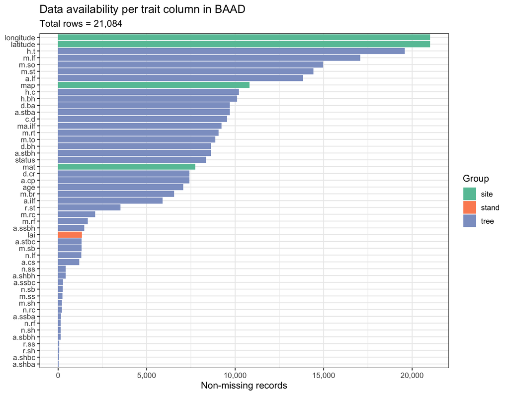

```r
avail <- dat %>%
  summarise(across(where(is.numeric), ~ sum(!is.na(.)))) %>%
  pivot_longer(everything(), names_to = "variable", values_to = "n") %>%
  left_join(dict %>% select(variable, units, group), by = "variable") %>%
  arrange(desc(n))

ggplot(avail, aes(x = reorder(variable, n), y = n, fill = group)) +
  geom_col() +
  coord_flip() +
  scale_y_continuous(labels = comma) +
  labs(x = NULL, y = "Non-missing records", fill = "Group",
       title = "Data availability per trait column in BAAD",
       subtitle = paste0("Total rows = ", format(n_rows, big.mark = ","))) +
  scale_fill_brewer(palette = "Set2")
```

# 3 Taxonomic coverage

## 3.1 Family breakdown

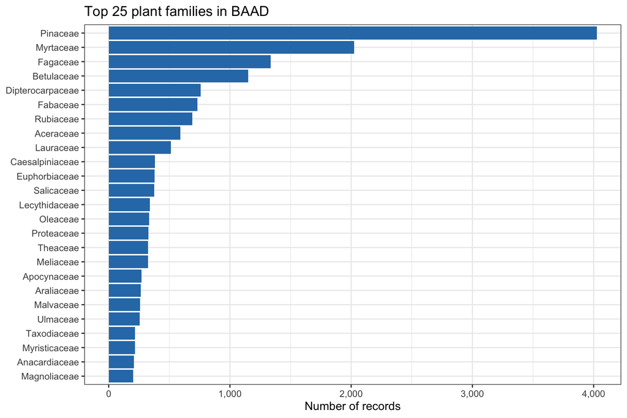

```r
fam <- dat %>%
  filter(!is.na(family)) %>%
  count(family, sort = TRUE)

ggplot(fam[1:25, ], aes(x = reorder(family, n), y = n)) +
  geom_col(fill = "#2c7bb6") +
  coord_flip() +
  scale_y_continuous(labels = comma) +
  labs(x = NULL, y = "Number of records",
       title = "Top 25 plant families in BAAD")
```

```r
kable(fam, col.names = c("Family", "N records"),
      caption = paste0("All ", nrow(fam), " families in BAAD"))
```

All 117 families in BAAD

| Family | N records |
| --- | --- |
| Pinaceae | 4026 |
| Myrtaceae | 2025 |
| Fagaceae | 1335 |
| Betulaceae | 1150 |
| Dipterocarpaceae | 758 |
| Fabaceae | 732 |
| Rubiaceae | 689 |
| Aceraceae | 591 |
| Lauraceae | 512 |
| Caesalpiniaceae | 381 |
| Euphorbiaceae | 379 |
| Salicaceae | 374 |
| Lecythidaceae | 339 |
| Oleaceae | 332 |
| Proteaceae | 326 |
| Theaceae | 325 |
| Meliaceae | 323 |
| Apocynaceae | 270 |
| Araliaceae | 265 |
| Malvaceae | 259 |
| Ulmaceae | 255 |
| Myristicaceae | 216 |
| Taxodiaceae | 216 |
| Anacardiaceae | 208 |
| Magnoliaceae | 202 |
| Juglandaceae | 200 |
| Verbenaceae | 191 |
| Bignoniaceae | 187 |
| Moraceae | 185 |
| Nothofagaceae | 172 |

[output cut: 87 more lines]

## 3.2 Top species by record count

```r
sp_counts <- dat %>%
  filter(!is.na(speciesMatched)) %>%
  count(speciesMatched, family, sort = TRUE)

kable(head(sp_counts, 40),
      col.names = c("Species (matched)", "Family", "N records"),
      caption = "Top 40 species by individual record count")
```

Top 40 species by individual record count

| Species (matched) | Family | N records |
| --- | --- | --- |
| Betula alleghaniensis | Betulaceae | 415 |
| Abies lasiocarpa | Pinaceae | 405 |
| Picea mariana | Pinaceae | 400 |
| Pinus sylvestris | Pinaceae | 391 |
| Acer saccharum | Aceraceae | 383 |
| Pinus contorta | Pinaceae | 333 |
| Eucalyptus saligna | Myrtaceae | 330 |
| Pinus taeda | Pinaceae | 320 |
| Corymbia maculata | Myrtaceae | 314 |
| Pinus banksiana | Pinaceae | 293 |
| Pinus ponderosa | Pinaceae | 272 |
| Fagus grandifolia | Fagaceae | 255 |
| Betula papyrifera | Betulaceae | 237 |
| Picea abies | Pinaceae | 218 |
| Eucalyptus grandis | Myrtaceae | 216 |
| Eucalyptus urophylla * Eucalyptus grandis (clone) | Myrtaceae | 211 |
| Betula pendula | Betulaceae | 208 |
| Abies balsamea | Pinaceae | 204 |
| Eucalyptus sideroxylon | Myrtaceae | 203 |
| Populus tremuloides | Salicaceae | 202 |
| Cryptomeria japonica | Taxodiaceae | 190 |
| Juglans major | Juglandaceae | 190 |
| Persea hintonii | Lauraceae | 188 |
| Toxicodendron trichocarpum | Anacardiaceae | 184 |
| Dendropanax arboreus | Araliaceae | 180 |
| Magnolia iltisiana | Magnoliaceae | 175 |
| Citharexylum mocinnii | Verbenaceae | 173 |
| Fraxinus uhdei | Oleaceae | 166 |
| Betula pubescens | Betulaceae | 165 |
| Pinus densiflora | Pinaceae | 154 |
| Picea glauca | Pinaceae | 148 |
| Dicorynia guianensis | Caesalpiniaceae | 137 |
| Picea glauca x Picea engelmannii | Pinaceae | 132 |
| Abies sachalinensis | Pinaceae | 129 |
| Fagus crenata | Fagaceae | 126 |
| Pseudotsuga menziesii | Pinaceae | 126 |
| Theobroma speciosum | Sterculiaceae | 119 |
| Ulmus americana | Ulmaceae | 119 |
| Aspidosperma parvifolium | Apocynaceae | 118 |
| Virola michelii | Myristicaceae | 118 |

## 3.3 Plant functional types (PFT)

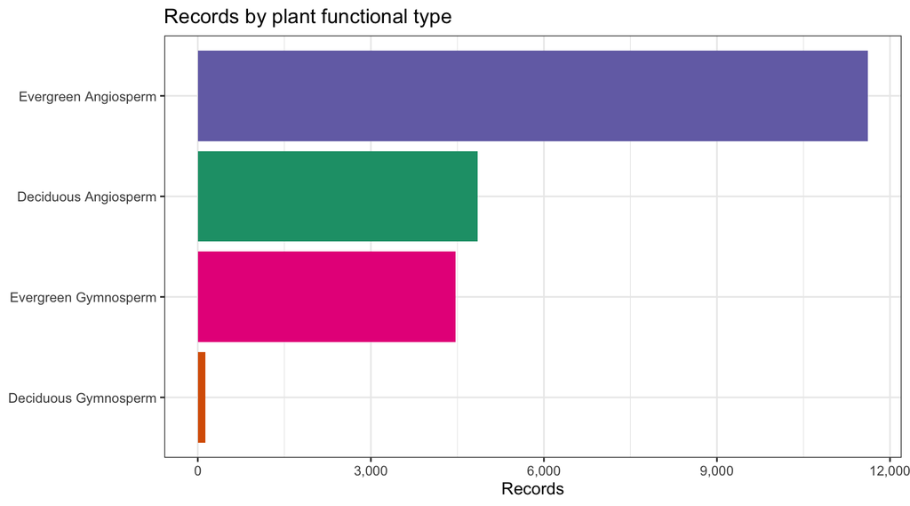

```r
pft_labels <- c(DA = "Deciduous Angiosperm", DG = "Deciduous Gymnosperm",
                EA = "Evergreen Angiosperm", EG = "Evergreen Gymnosperm")

dat %>%
  filter(!is.na(pft)) %>%
  count(pft) %>%
  mutate(label = pft_labels[pft]) %>%
  ggplot(aes(x = reorder(label, n), y = n, fill = pft)) +
  geom_col(show.legend = FALSE) +
  coord_flip() +
  scale_y_continuous(labels = comma) +
  scale_fill_brewer(palette = "Dark2") +
  labs(x = NULL, y = "Records", title = "Records by plant functional type")
```

# 4 Geographic coverage

## 4.1 Map of sampling locations

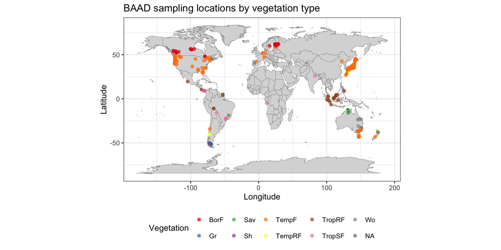

```r
world <- map_data("world")

site_pts <- dat %>%
  filter(!is.na(latitude), !is.na(longitude)) %>%
  distinct(studyName, latitude, longitude, vegetation)

ggplot() +
  geom_polygon(data = world, aes(x = long, y = lat, group = group),
               fill = "grey85", color = "grey60", linewidth = 0.2) +
  geom_point(data = site_pts, aes(x = longitude, y = latitude, color = vegetation),
             alpha = 0.7, size = 1.8) +
  coord_fixed(1.3) +
  scale_color_brewer(palette = "Set1", na.value = "grey50") +
  labs(title = "BAAD sampling locations by vegetation type",
       x = "Longitude", y = "Latitude", color = "Vegetation") +
  theme(legend.position = "bottom")
```

## 4.2 Vegetation type breakdown

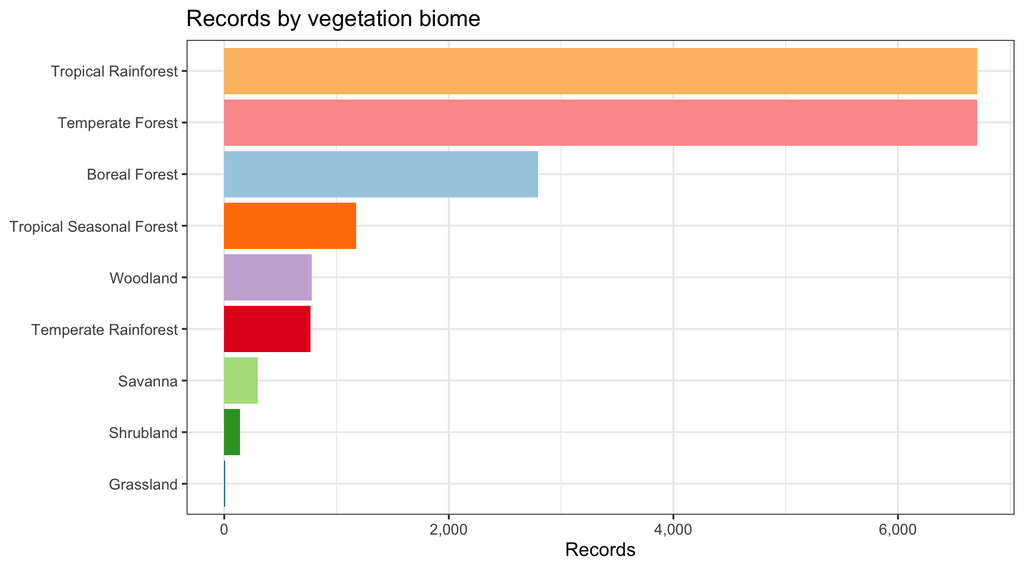

```r
veg_labels <- c(TempF  = "Temperate Forest", TropRF = "Tropical Rainforest",
                BorF   = "Boreal Forest",    TropSF = "Tropical Seasonal Forest",
                Wo     = "Woodland",         TempRF = "Temperate Rainforest",
                Sav    = "Savanna",          Sh     = "Shrubland",  Gr = "Grassland")

dat %>%
  filter(!is.na(vegetation)) %>%
  count(vegetation, sort = TRUE) %>%
  mutate(label = veg_labels[vegetation]) %>%
  ggplot(aes(x = reorder(label, n), y = n, fill = label)) +
  geom_col(show.legend = FALSE) +
  coord_flip() +
  scale_y_continuous(labels = comma) +
  scale_fill_brewer(palette = "Paired") +
  labs(x = NULL, y = "Records", title = "Records by vegetation biome")
```

## 4.3 Growing conditions

[figure not shown]

```r
gc_labels <- c(CG = "Common Garden", FE = "Field – Even-aged",
               FW = "Field – Wide-aged", GH = "Greenhouse",
               PM = "Plantation – Monoculture", PU = "Plantation – Uneven-aged")

dat %>%
  filter(!is.na(growingCondition)) %>%
  count(growingCondition, sort = TRUE) %>%
  mutate(label = ifelse(growingCondition %in% names(gc_labels),
                        gc_labels[growingCondition], growingCondition)) %>%
  ggplot(aes(x = reorder(label, n), y = n, fill = label)) +
  geom_col(show.legend = FALSE) +
  coord_flip() +
  scale_y_continuous(labels = comma) +
  scale_fill_brewer(palette = "Set3") +
  labs(x = NULL, y = "Records", title = "Records by growing condition")
```

# 5 Scaling relationships

All mass variables are in **kg**; all length/diameter variables are in **m**; all area variables are in **m²**. Scaling is assessed on log-transformed data following standard allometric practice. A regression slope $\beta$ in log-log space gives the power-law exponent: $Y = \alpha \cdot X^\beta$.

## 5.1 Total biomass vs. height

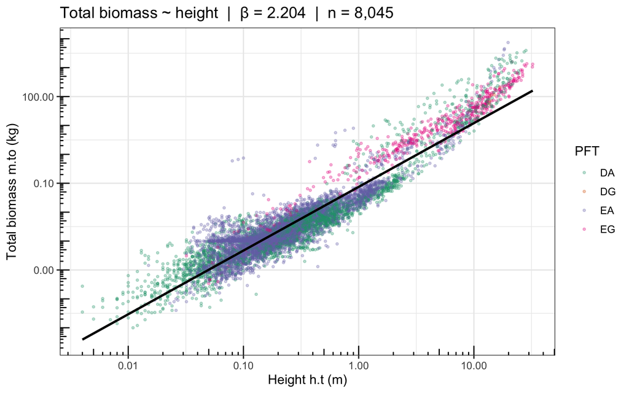

```r
d_mto_ht <- dat %>% filter(m.to > 0, h.t > 0)

lm1 <- lm(log10(m.to) ~ log10(h.t), data = d_mto_ht)
b1  <- round(coef(lm1)[2], 3)
a1  <- round(10^coef(lm1)[1], 4)
n1  <- nrow(d_mto_ht)

ggplot(d_mto_ht, aes(x = h.t, y = m.to, color = pft)) +
  geom_point(alpha = 0.3, size = 0.8) +
  geom_smooth(method = "lm", color = "black", se = TRUE,
              aes(group = 1), linewidth = 1) +
  scale_x_log10(labels = comma) +
  scale_y_log10(labels = comma) +
  scale_color_brewer(palette = "Dark2", na.value = "grey60") +
  labs(x = "Height h.t (m)", y = "Total biomass m.to (kg)", color = "PFT",
       title = paste0("Total biomass ~ height  |  β = ", b1,
                      "  |  n = ", format(n1, big.mark = ","))) +
  annotation_logticks()
```

> OLS in log-log space: m.to = 0.0751 × h.t^2.204 (n = 8,045). Note: OLS on log-transformed data is exploratory; use SMA regression for allometric inference.

## 5.2 Total biomass vs. stem diameter at breast height (DBH)

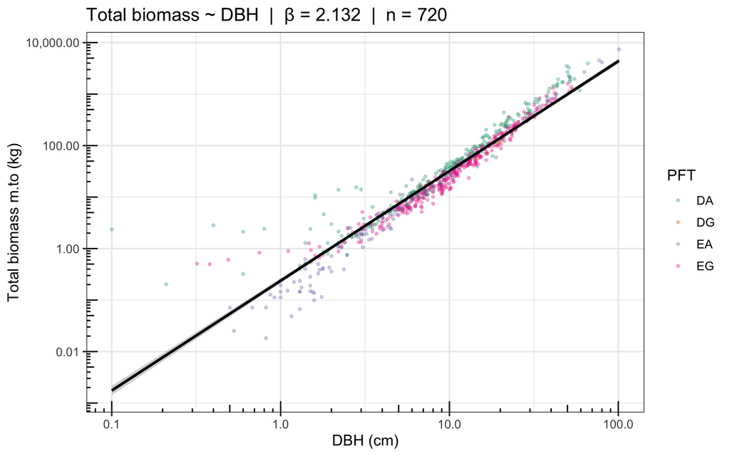

```r
d_mto_dbh <- dat %>% filter(m.to > 0, d.bh > 0)

lm2 <- lm(log10(m.to) ~ log10(d.bh), data = d_mto_dbh)
b2  <- round(coef(lm2)[2], 3)
a2  <- round(10^coef(lm2)[1], 4)
n2  <- nrow(d_mto_dbh)

ggplot(d_mto_dbh, aes(x = d.bh * 100, y = m.to, color = pft)) +
  geom_point(alpha = 0.3, size = 0.8) +
  geom_smooth(method = "lm", color = "black", se = TRUE,
              aes(group = 1), linewidth = 1) +
  scale_x_log10(labels = comma) +
  scale_y_log10(labels = comma) +
  scale_color_brewer(palette = "Dark2", na.value = "grey60") +
  labs(x = "DBH (cm)", y = "Total biomass m.to (kg)", color = "PFT",
       title = paste0("Total biomass ~ DBH  |  β = ", b2,
                      "  |  n = ", format(n2, big.mark = ","))) +
  annotation_logticks()
```

> OLS in log-log space: m.to = 4356.236 × d.bh^2.132 (n = 720). Diameter in metres for regression.

## 5.3 Leaf mass vs. total biomass

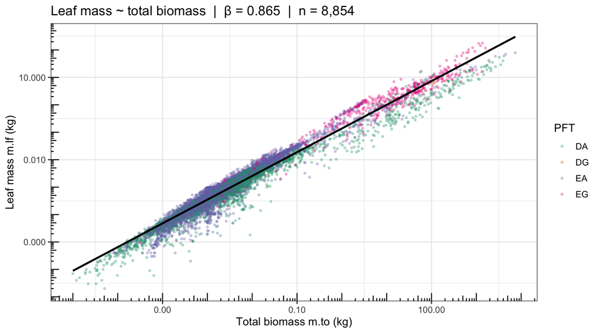

```r
d_lf_to <- dat %>% filter(m.lf > 0, m.to > 0)

lm3 <- lm(log10(m.lf) ~ log10(m.to), data = d_lf_to)
b3  <- round(coef(lm3)[2], 3)
a3  <- round(10^coef(lm3)[1], 5)
n3  <- nrow(d_lf_to)

ggplot(d_lf_to, aes(x = m.to, y = m.lf, color = pft)) +
  geom_point(alpha = 0.3, size = 0.8) +
  geom_smooth(method = "lm", color = "black", se = TRUE,
              aes(group = 1), linewidth = 1) +
  scale_x_log10(labels = comma) +
  scale_y_log10(labels = comma) +
  scale_color_brewer(palette = "Dark2", na.value = "grey60") +
  labs(x = "Total biomass m.to (kg)", y = "Leaf mass m.lf (kg)", color = "PFT",
       title = paste0("Leaf mass ~ total biomass  |  β = ", b3,
                      "  |  n = ", format(n3, big.mark = ","))) +
  annotation_logticks()
```

## 5.4 Stem mass vs. total biomass

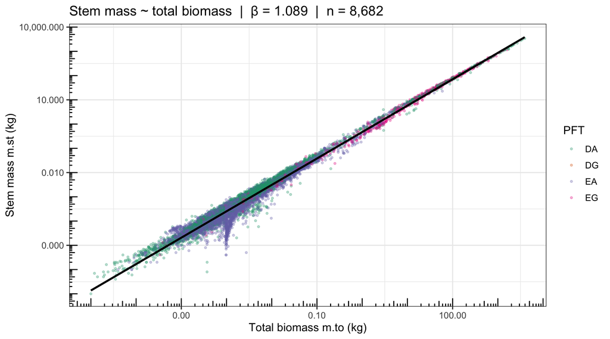

```r
d_st_to <- dat %>% filter(m.st > 0, m.to > 0)

lm4 <- lm(log10(m.st) ~ log10(m.to), data = d_st_to)
b4  <- round(coef(lm4)[2], 3)
n4  <- nrow(d_st_to)

ggplot(d_st_to, aes(x = m.to, y = m.st, color = pft)) +
  geom_point(alpha = 0.3, size = 0.8) +
  geom_smooth(method = "lm", color = "black", se = TRUE,
              aes(group = 1), linewidth = 1) +
  scale_x_log10(labels = comma) +
  scale_y_log10(labels = comma) +
  scale_color_brewer(palette = "Dark2", na.value = "grey60") +
  labs(x = "Total biomass m.to (kg)", y = "Stem mass m.st (kg)", color = "PFT",
       title = paste0("Stem mass ~ total biomass  |  β = ", b4,
                      "  |  n = ", format(n4, big.mark = ","))) +
  annotation_logticks()
```

## 5.5 Root mass vs. total biomass

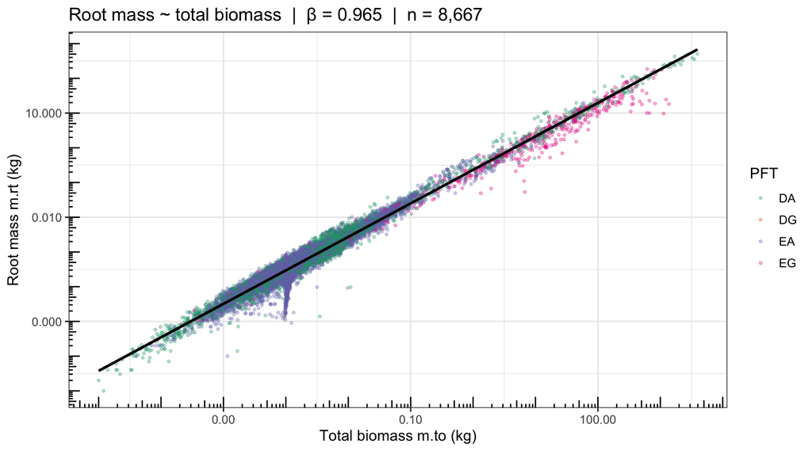

```r
d_rt_to <- dat %>% filter(m.rt > 0, m.to > 0)

lm5 <- lm(log10(m.rt) ~ log10(m.to), data = d_rt_to)
b5  <- round(coef(lm5)[2], 3)
n5  <- nrow(d_rt_to)

ggplot(d_rt_to, aes(x = m.to, y = m.rt, color = pft)) +
  geom_point(alpha = 0.3, size = 0.8) +
  geom_smooth(method = "lm", color = "black", se = TRUE,
              aes(group = 1), linewidth = 1) +
  scale_x_log10(labels = comma) +
  scale_y_log10(labels = comma) +
  scale_color_brewer(palette = "Dark2", na.value = "grey60") +
  labs(x = "Total biomass m.to (kg)", y = "Root mass m.rt (kg)", color = "PFT",
       title = paste0("Root mass ~ total biomass  |  β = ", b5,
                      "  |  n = ", format(n5, big.mark = ","))) +
  annotation_logticks()
```

## 5.6 Leaf area vs. total biomass

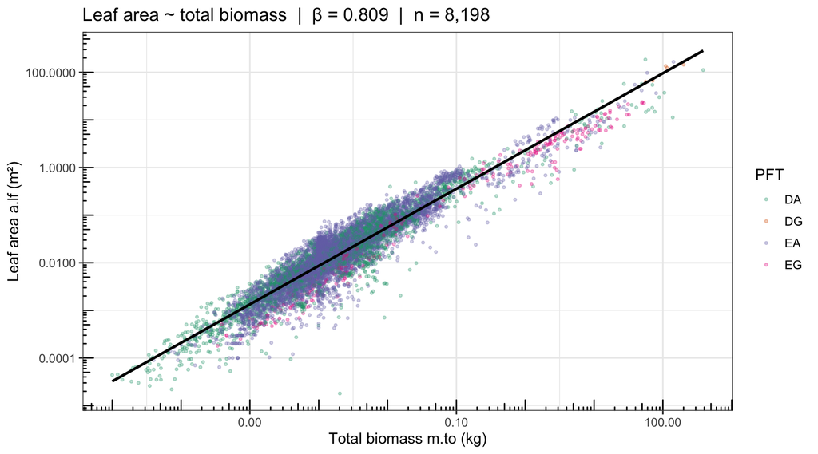

```r
d_alf_to <- dat %>% filter(a.lf > 0, m.to > 0)

lm6 <- lm(log10(a.lf) ~ log10(m.to), data = d_alf_to)
b6  <- round(coef(lm6)[2], 3)
n6  <- nrow(d_alf_to)

ggplot(d_alf_to, aes(x = m.to, y = a.lf, color = pft)) +
  geom_point(alpha = 0.3, size = 0.8) +
  geom_smooth(method = "lm", color = "black", se = TRUE,
              aes(group = 1), linewidth = 1) +
  scale_x_log10(labels = comma) +
  scale_y_log10(labels = comma) +
  scale_color_brewer(palette = "Dark2", na.value = "grey60") +
  labs(x = "Total biomass m.to (kg)", y = "Leaf area a.lf (m²)", color = "PFT",
       title = paste0("Leaf area ~ total biomass  |  β = ", b6,
                      "  |  n = ", format(n6, big.mark = ","))) +
  annotation_logticks()
```

## 5.7 Summary of scaling exponents (interspecific, OLS)

All regressions are OLS on log10-transformed data and are **exploratory only**. Standardized major axis (SMA) regression is recommended for allometric inference and will be applied in the formal analysis phase.

```r
exponents <- data.frame(
  Relationship      = c("m.to ~ h.t", "m.to ~ d.bh",
                        "m.lf ~ m.to", "m.st ~ m.to",
                        "m.rt ~ m.to", "a.lf ~ m.to"),
  Y_variable        = c("Total biomass (kg)", "Total biomass (kg)",
                        "Leaf mass (kg)", "Stem mass (kg)",
                        "Root mass (kg)", "Leaf area (m²)"),
  X_variable        = c("Height (m)", "DBH (m)",
                        "Total biomass (kg)", "Total biomass (kg)",
                        "Total biomass (kg)", "Total biomass (kg)"),
  OLS_exponent_beta = c(b1, b2, b3, b4, b5, b6),
  n                 = c(n1, n2, n3, n4, n5, n6)
)

kable(exponents, caption = "Interspecific OLS scaling exponents (log-log, all PFTs pooled). Exploratory only — see Methods note.")
```

Interspecific OLS scaling exponents (log-log, all PFTs pooled). Exploratory only — see Methods note.

| Relationship | Y_variable | X_variable | OLS_exponent_beta | n |
| --- | --- | --- | --- | --- |
| m.to ~ h.t | Total biomass (kg) | Height (m) | 2.204 | 8045 |
| m.to ~ d.bh | Total biomass (kg) | DBH (m) | 2.132 | 720 |
| m.lf ~ m.to | Leaf mass (kg) | Total biomass (kg) | 0.865 | 8854 |
| m.st ~ m.to | Stem mass (kg) | Total biomass (kg) | 1.089 | 8682 |
| m.rt ~ m.to | Root mass (kg) | Total biomass (kg) | 0.965 | 8667 |
| a.lf ~ m.to | Leaf area (m²) | Total biomass (kg) | 0.809 | 8198 |

# 6 Source studies

## 6.1 Studies sorted by record count

```r
study_counts <- dat %>%
  count(studyName, sort = TRUE) %>%
  left_join(refs %>% select(studyName, citation, doi), by = "studyName")

kable(study_counts, col.names = c("Study", "Records", "Citation", "DOI"),
      caption = paste0("All ", nrow(study_counts), " source studies in BAAD"))
```

All 176 source studies in BAAD

| Study | Records | Citation | DOI |
| --- | --- | --- | --- |
| Poorter1999 | 1612 | Poorter L (1999). ‘Growth responses of 15 rain-forest tree species to a light gradient: the relative importance of morphological and physiological traits.’ Functional Ecology, 13, pp. 396-410. | 10.1046/j.1365-2435.1999.00332.x |
| SaldanaAcosta2009 | 1268 | Saldaña-Acosta A, Meave JA and Sánchez-Velásquez LR (2009). ‘Seedling biomass allocation and vital rates of cloud forest tree species: Responses to light in shade house conditions.’ Forest Ecology and… | 10.1016/j.foreco.2009.07.027 |
| BondLamberty2002 | 943 | Bond-Lamberty B, Wang C and Gower ST (2002). ‘Aboveground and belowground biomass and sapwood area allometric equations for six boreal tree species of northern Manitoba.’ Canadian Journal of Forest Re… | 10.1139/x02-063 |
| Baraloto2006 | 867 | Baraloto C, Bonal D and Goldberg DE (2006). ‘Differential seedling growth response to soil resource availability among nine neotropical tree species.’ Journal of Tropical Ecology, 22(05), pp. 487-497. | 10.1017/S0266467406003439 |
| Markesteijn2009 | 662 | Markesteijn L and Poorter L (2009). ‘Seedling root morphology and biomass allocation of 62 tropical tree species in relation to drought- and shade-tolerance.’ Journal of Ecology, 97(2), pp. 311-325. | 10.1111/j.1365-2745.2008.01466.x |
| Selaya2010 | 630 | Selaya NG and Anten NPR (2010). ‘Leaves of pioneer and later-successional trees have similar lifetime carbon gain in tropical secondary forest.’ Ecology, 91, pp. 1102-1113. | 10.1890/08-2111.1 |
| Baltzer2007 | 584 | Baltzer JL and Thomas S (2007). ‘Physiological and morphological correlates of whole-plant light compensation point in temperate deciduous tree seedlings.’ Oecologia, 153(2), pp. 209-223. | 10.1007/s00442-007-0722-2 |
| Valladares2000 | 559 | Valladares F, Wright SJ, Lasso E, Kitajima K and Pearcy R (2000). ‘Plastic phenotypic response to light of 16 congeneric shrubs from a Panamanian rainforest.’ ECOLOGY, 81(7), pp. 1925-1936. | 10.1890/0012-9658(2000)081[1925:PPRTLO]2.0.CO;2 |
| Claveau2002 | 547 | Claveau Y, Messier C, Comeau PG and Coates KD (2002). ‘Growth and crown morphological responses of boreal conifer seedlings and saplings with contrasting shade tolerance to a gradient of light and hei… | 10.1139/x01-220 |
| Claveau2005 | 547 | Claveau Y, Messier C and Comeau PG (2005). ‘Interacting influence of light and size on aboveground biomass distribution in sub-boreal conifer saplings with contrasting shade tolerance.’ Tree Physiolog… | 10.1093/treephys/25.3.373 |
| Harja2012 | 528 | Harja D, Vincent G, Mulia R and van Noordwijk M (2012). ‘Tree shape plasticity in relation to crown exposure.’ Trees - Structure and Function, 26, pp. 1275-1285. | 10.1007/s00468-012-0703-x |
| Ximenes2004 | 504 | Ximenes F, Gardner W and Marchant J (2004). ‘Total biomass measurement and recovery of biomass in log products in spotted gum (Corymbia maculata) forests of SE NSW.’ National Carbon Accounting System … |  |
| King1996 | 479 | King DA (1996). ‘Allometry and life history of tropical trees.’ Journal of Tropical Ecology, 12, pp. 25-44. | 10.1017/S0266467400009299 |
| Delagrange0000a | 451 | Delagrange S (Unpublished). |  |
| Wenk0000 | 425 | Wenk EH and Falster DS (Unpublished). |  |
| Osunkoya2007 | 367 | Osunkoya OO, Omar-Ali K, Amit N, Dayan J, Daud DS and Sheng TK (2007). ‘Comparative height crown allometry and mechanical design in 22 tree species of Kuala Belalong rainforest, Brunei, Borneo.’ Ameri… | 10.3732/ajb.94.12.1951 |
| Portsmuth2006 | 343 | Portsmuth A and Niinemets Ü (2006). ‘Interacting controls by light availability and nutrient supply on biomass allocation and growth of Betula pendula and B. pubescens seedlings.’ Forest Ecology and M… | 10.1016/j.foreco.2006.02.020 |
| Aiba2005 | 318 | Aiba M and Nakashizuka T (2005). ‘Sapling structure and regeneration strategy in 18 Shorea species co-occurring in a tropical rainforest.’ Annals of Botany, 96(2), pp. 313-321. | 10.1093/aob/mci179 |
| Brown1978 | 310 | Brown JK (1978). ‘INT-197: Weight and density of crowns of Rocky Mountain conifers.’ U.S. Department of Agriculture, Forest Service, Intermountain Forest and Range Experiment Station. |  |
| Delagrange0000b | 257 | Delagrange S (Unpublished). |  |
| Aiba2007 | 248 | Aiba M and Nakashizuka T (2007). ‘Variation in juvenile survival and related physiological traits among dipterocarp species co-existing in a Bornean forest.’ Journal of Vegetation Science, 18(3), pp. … | 10.1111/j.1654-1103.2007.tb02550.x |
| Lusk2012 | 239 | Lusk CH, Pérez-Millaqueo MM, Saldaña A, Burns BR, Laughlin DC and Falster DS (2012). ‘Seedlings of temperate rainforest conifer and angiosperm trees differ in leaf area display.’ Annals of Botany, 110… | 10.1093/aob/mcs095 |
| vanBreugel2011 | 236 | Breugel Mv, Ransijn J, Craven D, Bongers F and Hall JS (2011). ‘Estimating carbon stock in secondary forests: Decisions and uncertainties associated with allometric biomass models.’ Forest Ecology and… | 10.1016/j.foreco.2011.07.018 |
| Williams2005 | 220 | Williams R, Zerihun A, Montagu K, Hoffman M, Hutley L and Chen X (2005). ‘Allometry for estimating aboveground tree biomass in tropical and subtropical eucalypt woodlands: towards general predictive e… |  |
| Epron2011 | 216 | Epron D, Laclau JP, Almeida JCR, Goncalves JLM, Ponton S, Sette CR, Delgado-Rojas JS, Bouillet J and Nouvellon Y (2012). ‘Do changes in carbon allocation account for the growth response to potassium a… | 10.1093/treephys/tpr107 |
| Ghannoum2010a | 215 | Ghannoum O, Phillips NG, Conroy JP, Smith RA, Attard RD, Woodfield R, Logan BA, Lewis JD and Tissue DT (2010). ‘Exposure to preindustrial, current and future atmospheric CO2 and temperature differenti… | 10.1111/j.1365-2486.2009.02003.x |
| Albrektson1984 | 192 | Albrektson A (1984). ‘Sapwood basal area and needle mass of Scots pine (Pinus sylvestris L.) trees in central Sweden.’ Forestry, 57(1), pp. 35-43. | 10.1093/forestry/57.1.35 |
| Burger1953 | 189 | Burger H (1953). ‘Holz, Blattmenge und Zuwachs. Fichten in gleichaltrigen Hochwald. Mitt. Schweiz.’ Mitteilungen der Schweizerischen Anstalt för das forstliche Versuchswesen, 29, pp. 38-130. |  |
| Roth2007 | 184 | Roth BE, Jokela EJ, Martin TA, Huber DA and White TL (2007). ‘Genotype x environment interactions in selected loblolly and slash pine plantations in the Southeastern United States.’ Forest Ecology and… | 10.1016/j.foreco.2006.10.010 |
| Osada2005 | 179 | Osada N (2005). ‘Branching, biomass distribution, and light capture efficiency in a pioneer tree, Rhus trichocarpa, in a secondary forest.’ Canadian Journal of Botany, 83(12), pp. 1590-1598. | 10.1139/b05-133 |

[output cut: 146 more lines]

# 7 Key caveats and notes for downstream analysis